# Lab 02 - Propensity Scores

Abhi Jain

2022-02-23

```r
library(tidyverse)
library(ggdag)
library(broom)
```

# Exercise 1

good_service_exp ~ age + sex + race + income + attitude + attire + past_spending

spending ~ income + age + sex + past_spending

past_spending ~ income + age + sex

income ~ age + sex + race + education

# Exercise 2

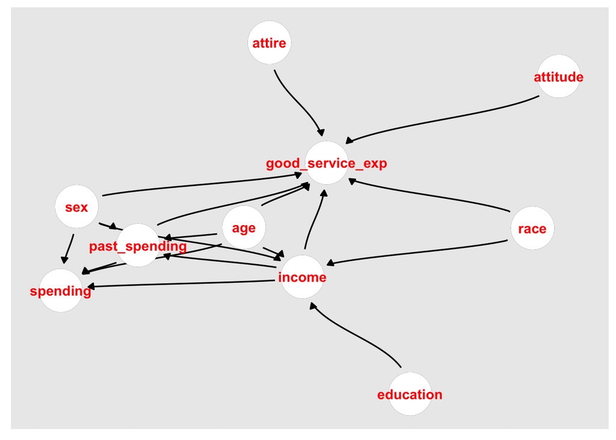

```r
dag1 <- dagify(
  good_service_exp ~ age + sex + race + income + attitude + attire + past_spending,
  spending ~ income + age + sex + past_spending,
  past_spending ~ income + age + sex,
  income ~ age + sex + race + education,
  exposure = "good_service_exp",
  outcome = "spending"
)

dag1 %>% ggdag(text = F, edge_type = "diagonal") + geom_dag_node(col="white") + geom_dag_text(col="red") + theme_dag_gray()
```

# Exercise 3

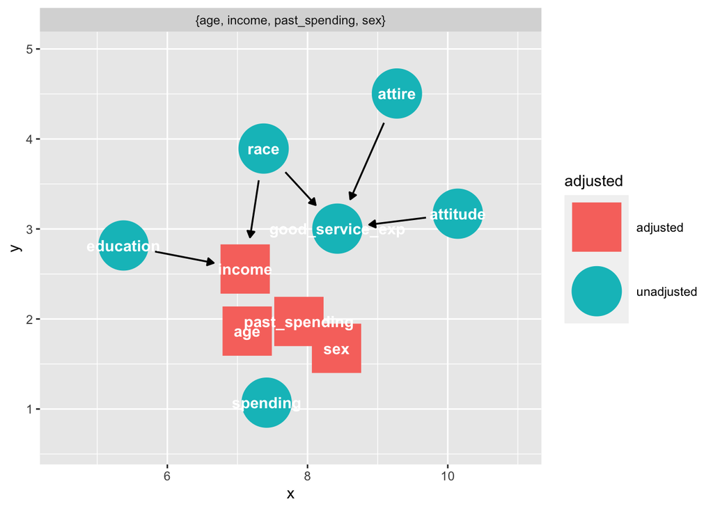

```r
dag1 %>% ggdag_adjustment_set()
```

We can adjust for age, income, sex, and past spending to close the backdoor path.

# Exercise 4

```r
customer_data <- read_csv("customer_satisfaction.csv")
```

# Exercise 5

```r
glimpse(customer_data)
```

```
## Rows: 1,265
## Columns: 13
## $ gender                     <chr> "male", "male", "female", "female", "male",…
## $ age                        <dbl> 44.593695, 81.081522, 39.785151, 44.163145,…
## $ education                  <dbl> 2, 0, 4, 3, 4, 1, 3, 2, 2, 3, 0, 2, 3, 2, 1…
## $ geographic_location        <chr> "Northeast", "Northeast", "Northeast", "Nor…
## $ income                     <chr> "$60,000+", "< $60,000", "$60,000+", "$60,0…
## $ married                    <chr> "yes", "yes", "yes", "yes", "yes", "yes", "…
## $ n_kids                     <dbl> 1, 0, 0, 0, 0, 1, 0, 0, 0, 0, 0, 2, 0, 0, 0…
## $ has_pets                   <dbl> 1, 1, 1, 1, 1, 1, 1, 1, 1, 1, 1, 1, 1, 1, 1…
## $ former_customer_service    <chr> "no", "no", "no", "no", "no", "no", "no", "…
## $ previous_spend             <dbl> 130.12708, 560.90251, 376.20065, 202.02611,…
## $ new_customer               <chr> "no", "no", "no", "no", "no", "no", "no", "…
## $ satisfied_customer_service <dbl> 0, 0, 1, 1, 1, 1, 1, 1, 1, 0, 0, 1, 1, 1, 0…
## $ next_spend                 <dbl> 368.3227, 733.1112, 614.8090, 448.7381, 663…
```

```r
dag2 <- dagify(
  good_service_exp ~ age + sex + race + income + attitude + attire + past_spending,
  spending ~ income + age + sex + past_spending,
  past_spending ~ income + age + sex,
  income ~ age + sex + race + education,
  exposure = "good_service_exp",
  outcome = "spending",
  latent = c("attire", "race", "attitude")
)
```

The following variables from our DAG are available in the data: age, sex, income, and past spending. While we could treat the variable former_customer_service as a proxy for attitude since someone who is formerly a customer service employee will likely be more respectful to customer service staff, I don’t think it does a good enough job of capturing all the features of attitude, so we will set attitude as a latent variable. Attire and race are also latent.

# Exercise 6/7

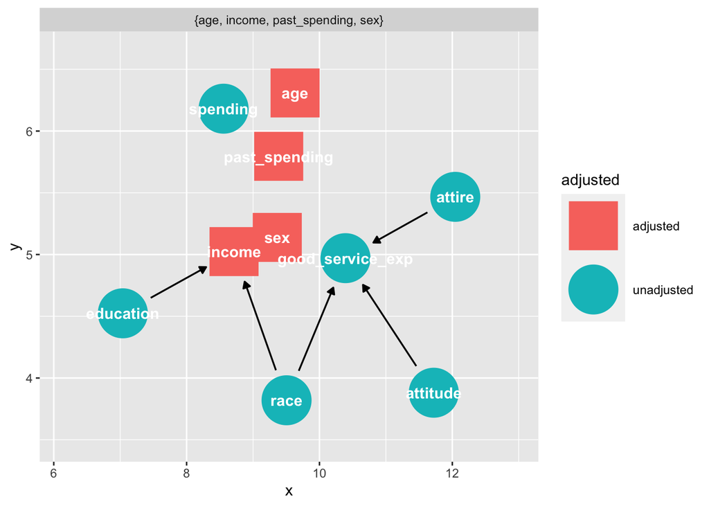

```r
dag2 %>% ggdag_adjustment_set()
```

Now we calculate the propensity scores using variables from the adjustment set: age, sex, income, and past spending.

```r
customer_data <- glm(satisfied_customer_service ~ gender + age + income + previous_spend, data = customer_data, family = binomial()) %>%
  augment(type.predict = "response", data = customer_data)
```

# Exercise 8

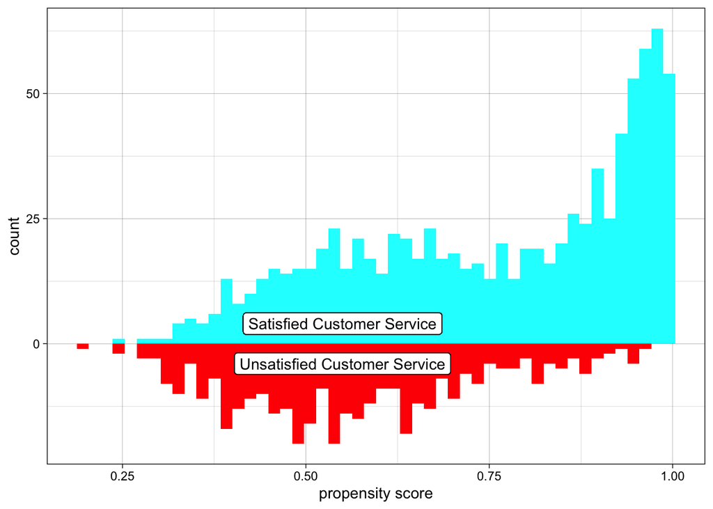

```r
df_plot_ps <- customer_data %>%
  tidyr::pivot_wider(names_from = satisfied_customer_service,
                     values_from = .fitted,
                     names_prefix = "scs_p")

ggplot(df_plot_ps) +
  geom_histogram(bins = 50,
                 aes(x = scs_p1),
                 fill = "cyan") +
  geom_histogram(bins = 50,
                 aes(x = scs_p0,
                     y = - stat(count)),
                 fill = "red") +
  scale_y_continuous("count", label = abs) +
  scale_x_continuous("propensity score") +
  geom_label(
    label = "Satisfied Customer Service",
    x = 0.55,
    y = 4
  ) +
  geom_label(
    label = "Unsatisfied Customer Service",
    x = 0.55,
    y = -4
  ) + theme_linedraw()
```

Above is a mirrored histogram of propensity scores for shoppers who had a satisfying customer experience on the top and shoppers who had an unsatisfying customer experience on the bottom. As we can see from the mirrored histogram, the propensity scores for the shoppers who had a satisfying customer experience is heavily skewed left, which indicates that the propensity score model had a strong ability to predict whether a shopper experienced satisfying customer experience. On the other hand, the histogram for the unsatisfied customer experience population is fairly normal with a mean around 0.55.